# PCA

#### Preparation

```python
# -*- coding: utf-8 -*-

print (__doc__)

from mpl_toolkits.mplot3d import Axes3D
from mlxtend.plotting import plot_decision_regions
from PIL import Image
from sklearn import preprocessing
from sklearn.model_selection import train_test_split
from sklearn.naive_bayes import GaussianNB
#from mlxtend.plotting import plot_decision_regions
from sklearn.decomposition import PCA
import numpy as np
import matplotlib.pyplot as plt
import matplotlib.colors as colours
import glob
import os
from random import randrange
from sys import getsizeof


import numpy as np
import matplotlib.pyplot as plt
from mpl_toolkits.mplot3d import Axes3D
from sklearn import datasets, svm
from sklearn.model_selection import train_test_split
from sklearn.decomposition import PCA
from sklearn.metrics import accuracy_score
from matplotlib.colors import Normalize
from sklearn.preprocessing import StandardScaler
from sklearn.model_selection import StratifiedShuffleSplit
from sklearn.model_selection import GridSearchCV
from sklearn.model_selection import ParameterGrid
import random

#IRIS DATASET
from sklearn import datasets
iris = datasets.load_iris()
X = iris.data
y = iris.target

Normalized_X = StandardScaler().fit_transform(X)
```

```
Automatically created module for IPython interactive environment
```

#### Definition

Principal component analysis (PCA) is a statistical procedure that uses an orthogonal transformation to convert the variables of a dataset into a new set of variables which are linearly uncorrelated and called principal components. The principal components are ranked according to the variance of data along them. This technique can be used to reduce the dimensionality of the dataset by considering just the most important principal components.

In order to reduce the dimensionality of a dataset $X$ with $n$ variables to a new dataset with $k$ variables using PCA the following steps have to be followed:

standardize the data calculate the Eigenvectors and Eigenvalues from the covariance matrix or correlation matrix, or perform Singular Vector Decomposition. sort the Eigenvectors according to their Eigenvalues in decreasing order build the $n×k$-dimensional projection matrix $W$ by putting the top $k$ Eigenvectors into the columns of $W$ transform the dataset $X$ by multiplying it with $W$: $X_{t} = XW$ We apply PCA to the dataset in order to reduce the number of features.

#### Application

```
PC:
 [[ 0.52237162 -0.26335492  0.58125401  0.56561105]
 [ 0.37231836  0.92555649  0.02109478  0.06541577]]
dimensioni X matrix ==  (150, 4)
dimensione matrice delle Principal Component per PCA(2) ==  (150, 2)
dimensione matrice delle Principal Component per PCA(.99) ==  (150, 3)
```

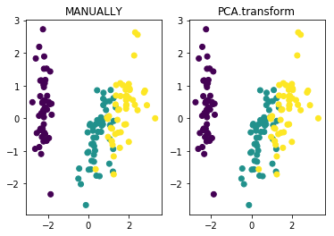

```python
#Definitions of PCA:
pca_2 = PCA(2) #PCA function with n_components = 2!
pca_3 = PCA(.99) #we are asking of a # of components that gives variance >= 99% (3 comp)


#Applications of PCA(2):
pca_2.fit(Normalized_X)
pca_X = pca_2.transform(Normalized_X)
#pca_X = transformed Matrix; rows = samples, columns = value of projection on principal components

#components are accessible by object: pca_2.components_
print("PC: \n",pca_2.components_)
print("dimensioni X matrix == ",Normalized_X.shape)
print("dimensione matrice delle Principal Component per PCA(2) == ",pca_X.shape)

#Applications of PCA(.99):
pca_3.fit(Normalized_X)
pca3_X = pca_3.transform(Normalized_X)
print("dimensione matrice delle Principal Component per PCA(.99) == ",pca3_X.shape,)

#Manual Application
X_T = np.dot(Normalized_X, pca_2.components_[0:2].T)

#Visualization
plt.subplot(1,2,1).set_title("MANUALLY")#MATPLOTLIB <-- subplot(nrighe, ncolonne, id_elemento)
plt.scatter(X_T[:,0],X_T[:,1],c=y)
plt.subplot(1,2,2).set_title("PCA.transform")
plt.scatter(pca_X[:,0],pca_X[:,1],c=y)
plt.show()
```